# Part II - Explanatory Slide Deck (Outcome)

## Communicating Data Findings on Prosper Loan Data Exploration and Visualization

## By Ayomide (Enoch) Fadeyi

## Investigation Overview

## General Research Question guiding my analysis

### What are the main driving factors of outcome of loan?

> In part one of this project, the above question and a host of others have been answered during the exploratory data analysis stage. However, in this part two, I intend to carry out explanatory data analysis, explaining my findings using visuals and interpretation of these visuals. I will be adding a summary of key insights as contained in the README.md. This will helps my notebook to stay aligned to the key insights I want to include in my slide deck.

## Key Insights for Presentation

*** Those with low prosper rating are found to have highest rates of default in credits.

## Dataset Overview

## Introduction

> Introducing my dataset *** Loan Data from Prosper: This data set contains 113,937 observations (loans) with 81 features (variables/columns) on each loan, including loan amount, borrower rate (or interest rate), current loan status, borrower income, and many others. Here is the link to the data dictionary to understand the dataset's variables: https://docs.google.com/spreadsheets/d/1gDyi_L4UvIrLTEC6Wri5nbaMmkGmLQBk-Yx3z0XDEtI/edit#gid=0

### Observation 1

The majority of borrowers are employed. It is worthy of note that full-time and self employed workers request for more loans than the rest.

### Visualization 1

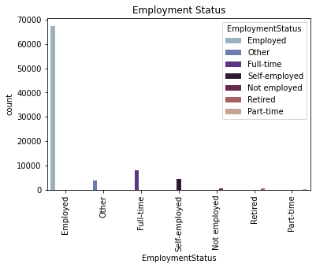

### Observation 2

With a boundary of mean and 3 times standard deviations distribution of monthly income still has noticeable right skew but now we can see that mode is about 5000.

### Visualization 2

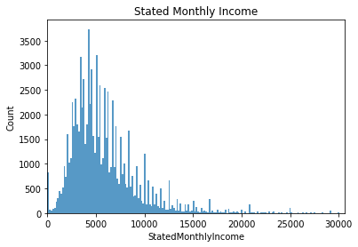

### Observation 3

As seen in the below visual, there is a significant difference between the completed Loan and defaulted Loan of employed and unemployed. The employed tend to complete their loans than the unemployed

### Visualization 3

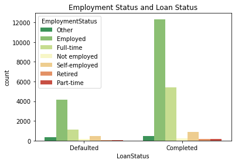

### Observation 4

The debt consolidation category have the highest frequency among all of the categories, followed by other category.

### Visualization 4

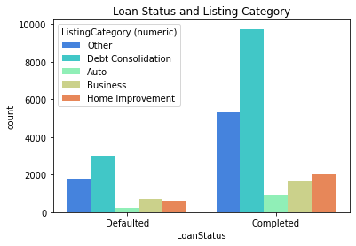

### Visualization 5

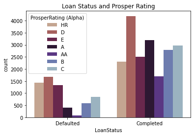

### Observation 6

From the above graph, we can see completed credits are more than defaulted loans. This clearly tells us that Prosper Loan Facility is doing fine.

### Visualization 6

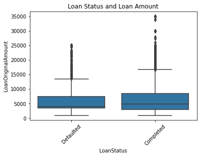

### Visualization 7

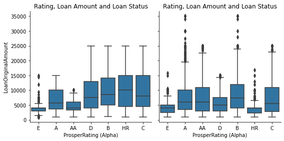

### Observation 8

1. Business listing category have larger amount of completed loans.
2. Home improvement have larger amount of defauled loans.

### Visualization 8

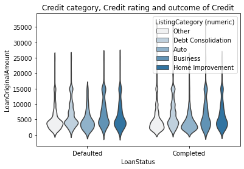

I got an interesting finding from the correlation plot above. Loan Original Amount and Investors have a high positive correlation of 0.53. This implies an increase in investors leads to an increase in the amount of Loan available.

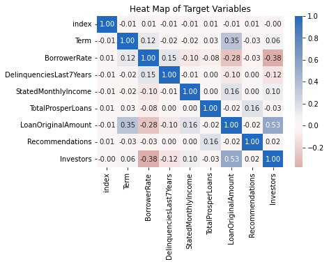

# Talk about some of the relationships you observed in this part of the investigation. Were there features that strengthened each other in terms of looking at your feature(s) of interest?

My initial assumptions were strengthened. Most of the defaulted credits comes from individuals with low Prosper rating and Business category tend to have larger amount.

# Were there any interesting or surprising interactions between features?

## Conclusions

### Summary

> My initial assumptions were strengthened.

*** Most of the defaulted credits comes from individuals with low Prosper rating

*** The employed tend to complete their loans than the unemployed

### What are the main driving factors of outcome of loan?

The main driving factors of outcome of loan from the analysis conducted in the project include the following:

1. Employment
2. Prosper Rating
3. Business Category

### Steps taken during my data exploration.

1. Question: The first step I took to conduct this project is to pose a general research question. From this one question, several other questions were asked and answered.
2. Analyse: Next, I used different libraries and functions to analyse the data in a bid to proffer answers to the questions posed.
3. Visualize: Then, I moved on to visualizing the data to aid comprehension and understanding of the findings from my analysis.
4. Observation: Lastly, I point out and explain my observations and findings to each of this question.

## Further Research

I will like to carry out a further machine learning and predictive analytics based on the interesting relatioinships I discovered in this analysis.